# 326.212 Homework 3

2022-11-08

## 2021-12659

# Prerequisites

```r
library(tidyverse)
library(nycflights13)
library(stringr)
library(lubridate)
```

# Textbook 13.2.1

## Problem 1

flights 와 airports table을 합칠 수있습니다. 그리고 flights에서는 각 비행기마다의 origin(출발지)와 dest(도착지) 변수가 airports에서는 lon(경도)와 lat(위도) 변수가 필요합니다.

# Textbook 13.3.1

## Problem 2

### 1

```r
Lahman::Batting %>% count(playerID, yearID, stint) %>% filter(n > 1)
```

```
## [1] playerID yearID   stint    n
## <0 행> <또는 row.names의 길이가 0입니다>
```

playerID, yearID, stint

### 2

```r
babynames::babynames %>% count(name, year, sex) %>% filter(n > 1)
```

```
## # A tibble: 0 × 4
## # … with 4 variables: name <chr>, year <dbl>, sex <chr>, n <int>
```

name, year, sex

### 3

```r
nasaweather::atmos %>% count(lat, long, year, month) %>% filter(n > 1)
```

```
## # A tibble: 0 × 5
## # … with 5 variables: lat <dbl>, long <dbl>, year <int>, month <int>, n <int>
```

lat, long, year, month

```r
fueleconomy::vehicles %>% count(id) %>% filter(n > 1)
```

```
## # A tibble: 0 × 2
## # … with 2 variables: id <dbl>, n <int>
```

id

### 5

```r
diamonds
```

```
## # A tibble: 53,940 × 10
##    carat cut       color clarity depth table price     x     y     z
##    <dbl> <ord>     <ord> <ord>   <dbl> <dbl> <int> <dbl> <dbl> <dbl>
##  1  0.23 Ideal     E     SI2      61.5    55   326  3.95  3.98  2.43
##  2  0.21 Premium   E     SI1      59.8    61   326  3.89  3.84  2.31
##  3  0.23 Good      E     VS1      56.9    65   327  4.05  4.07  2.31
##  4  0.29 Premium   I     VS2      62.4    58   334  4.2   4.23  2.63
##  5  0.31 Good      J     SI2      63.3    58   335  4.34  4.35  2.75
##  6  0.24 Very Good J     VVS2     62.8    57   336  3.94  3.96  2.48
##  7  0.24 Very Good I     VVS1     62.3    57   336  3.95  3.98  2.47
##  8  0.26 Very Good H     SI1      61.9    55   337  4.07  4.11  2.53
##  9  0.22 Fair      E     VS2      65.1    61   337  3.87  3.78  2.49
## 10  0.23 Very Good H     VS1      59.4    61   338  4     4.05  2.39
## # … with 53,930 more rows
```

```r
ggplot2::diamonds %>% count(clarity, depth, color, clarity, carat, cut, table, price)%>% filter(n > 1)
```

```
## # A tibble: 735 × 8
##    clarity depth color carat cut     table price     n
##    <ord>   <dbl> <ord> <dbl> <ord>   <dbl> <int> <int>
##  1 I1       57.3 E      1.52 Good       58  3105     2
##  2 SI2      57.5 E      0.71 Good       58  1783     2
##  3 SI2      57.5 G      1.5  Good       63  6006     2
##  4 SI2      58.1 F      0.51 Premium    59  1052     2
##  5 SI2      58.4 G      0.52 Premium    62  1076     2
##  6 SI2      58.5 F      1.5  Premium    60  7644     2
##  7 SI2      58.8 I      1    Ideal      55  3629     2
##  8 SI2      59.1 E      1.1  Premium    60  4967     2
##  9 SI2      59.9 E      0.53 Premium    58   984     2
## 10 SI2      59.9 H      1.01 Premium    59  4242     2
## # … with 725 more rows
```

없다고 생각합니다.

# Textbook 13.4.6

## Problem 3

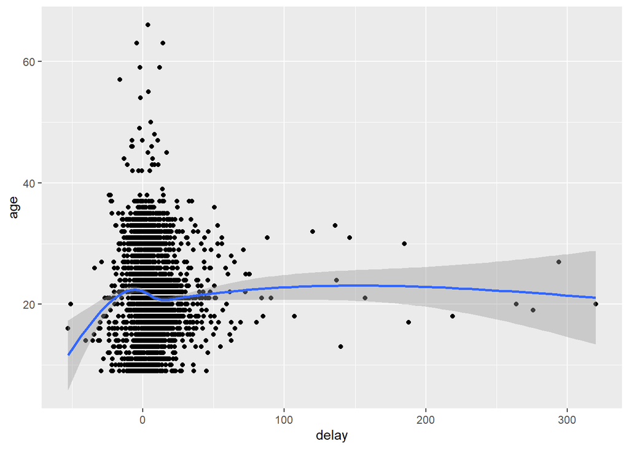

```r
flights %>% group_by(tailnum) %>% summarize(delay = mean(arr_delay, na.rm = T)) %>% inner_join(select(planes, tailnum, year), by = "tailnum") %>% mutate(age = year(today()) - year) %>% ggplot(mapping = aes(x = delay, y = age)) + geom_point() + geom_smooth()
```

비행기의 나이와 delay에는 별다른 관계가 있다고 생각하지 않습니다.

# Textbook 13.5.1

## Problem 1

```r
flights %>% filter(is.na(tailnum))
```

```
## # A tibble: 2,512 × 19
##     year month   day dep_time sched_de…¹ dep_d…² arr_t…³ sched…⁴ arr_d…⁵ carrier
##    <int> <int> <int>    <int>      <int>   <dbl>   <int>   <int>   <dbl> <chr>
##  1  2013     1     2       NA       1545      NA      NA    1910      NA AA
##  2  2013     1     2       NA       1601      NA      NA    1735      NA UA
##  3  2013     1     3       NA        857      NA      NA    1209      NA UA
##  4  2013     1     3       NA        645      NA      NA     952      NA UA
##  5  2013     1     4       NA        845      NA      NA    1015      NA 9E
##  6  2013     1     4       NA       1830      NA      NA    2044      NA 9E
##  7  2013     1     5       NA        840      NA      NA    1001      NA 9E
##  8  2013     1     7       NA        820      NA      NA     958      NA 9E
##  9  2013     1     8       NA       1645      NA      NA    1838      NA US
## 10  2013     1     9       NA        755      NA      NA    1012      NA 9E
## # … with 2,502 more rows, 9 more variables: flight <int>, tailnum <chr>,
## #   origin <chr>, dest <chr>, air_time <dbl>, distance <dbl>, hour <dbl>,
## #   minute <dbl>, time_hour <dttm>, and abbreviated variable names
## #   ¹sched_dep_time, ²dep_delay, ³arr_time, ⁴sched_arr_time, ⁵arr_delay
```

tailnum이 NA인 값들만 필터링했더니 dep_time도 NA가 나왔습니다.

```r
flights %>% filter(is.na(tailnum), !is.na(arr_time))
```

```
## # A tibble: 0 × 19
## # … with 19 variables: year <int>, month <int>, day <int>, dep_time <int>,
## #   sched_dep_time <int>, dep_delay <dbl>, arr_time <int>,
## #   sched_arr_time <int>, arr_delay <dbl>, carrier <chr>, flight <int>,
## #   tailnum <chr>, origin <chr>, dest <chr>, air_time <dbl>, distance <dbl>,
## #   hour <dbl>, minute <dbl>, time_hour <dttm>
```

tailnum이 NA이고 arr_time이 NA가 아닌 값을 필터링 했더니 0개 였습니다.

flights 데이터에서 tailnum이 NA인 값들은 비행기가 출발하지 않았음을 의미합니다.

```r
flights %>%
  anti_join(planes, by = "tailnum")
```

```
## # A tibble: 52,606 × 19
##     year month   day dep_time sched_de…¹ dep_d…² arr_t…³ sched…⁴ arr_d…⁵ carrier
##    <int> <int> <int>    <int>      <int>   <dbl>   <int>   <int>   <dbl> <chr>
##  1  2013     1     1      558        600      -2     753     745       8 AA
##  2  2013     1     1      559        600      -1     941     910      31 AA
##  3  2013     1     1      600        600       0     837     825      12 MQ
##  4  2013     1     1      602        605      -3     821     805      16 MQ
##  5  2013     1     1      608        600       8     807     735      32 MQ
##  6  2013     1     1      611        600      11     945     931      14 UA
##  7  2013     1     1      623        610      13     920     915       5 AA
##  8  2013     1     1      624        630      -6     840     830      10 MQ
##  9  2013     1     1      628        630      -2    1137    1140      -3 AA
## 10  2013     1     1      629        630      -1     824     810      14 AA
## # … with 52,596 more rows, 9 more variables: flight <int>, tailnum <chr>,
## #   origin <chr>, dest <chr>, air_time <dbl>, distance <dbl>, hour <dbl>,
## #   minute <dbl>, time_hour <dttm>, and abbreviated variable names
## #   ¹sched_dep_time, ²dep_delay, ³arr_time, ⁴sched_arr_time, ⁵arr_delay
```

flights에 기록된 tailnum이 plane에 없는 경우에 대해 carrier에서 AA와 MQ가 많이 보였습니다.

```r
flights %>%
  anti_join(planes, by = "tailnum") %>% count(carrier, sort = T)
```

```
## # A tibble: 10 × 2
##    carrier     n
##    <chr>   <int>
##  1 MQ      25397
##  2 AA      22558
##  3 UA       1693
##  4 9E       1044
##  5 B6        830
##  6 US        699
##  7 FL        187
##  8 DL        110
##  9 F9         50
## 10 WN         38
```

plane과 일치하는 tailnum이 없는 경운느 항공사가 MQ 또는 AA인 경우가 거의 대부분이었습니다.

# Textbook 14.2.5

## Problem 2

```r
str_c(c("x", "y", "z"), sep = ", ")
```

```
## [1] "x" "y" "z"
```

```r
str_c(c("x", "y", "z"), collapse = ", ")
```

```
## [1] "x, y, z"
```

```r
str_c("x", "y", "z", sep = ",")
```

```
## [1] "x,y,z"
```

```r
str_c("x", "y", "z", collapse = ",")
```

```
## [1] "xyz"
```

```r
str_c(c("x", "y", "z"), "A", sep = ",")
```

```
## [1] "x,A" "y,A" "z,A"
```

```r
str_c(c("x", "y", "z"), "A", collapse = ",")
```

```
## [1] "xA,yA,zA"
```

```r
str_c(c("x", "y", "z"), "A", sep =",", collapse = ",")
```

```
## [1] "x,A,y,A,z,A"
```

sep은 입력된 값들 사이에 삽입되는 문자열이다. 그리고 벡터화된 값에 대해서는 길이가 짧은 요소를 반복하여 길이가 가장 긴 벡터만큼의 문자열을 만든다. 하지만 collapase는 하나의 문자열로 결합시키고 요소들을 구분하기 위해 사용되는 문자열이다.

# Textbook 14.3.1.1

## Problem 1

“\”은 다음 문자를 escape합다. ”\\” 은 정규표현식에서 인식되어 다음문자를 escape합니다. “\\\”은 정규표현식의 인식되고 r에서 다음 문자를 escape하는 걸로 인식합니다. 그래서”\\\\“가 정규표현식에서”\“로 사용됩니다.

# Textbook 14.3.2.1

## Problem 2

### 1

```r
str_view(words, "^y", match = T)
```

[interactive chart not shown]

### 2

```r
str_view(words, "x$", match = T)
```

[interactive chart not shown]

### 3

```r
str_view(words, "^...$", match = T)
```

[interactive chart not shown]

### 4

```r
str_view(words, ".......", match = T)
```

[interactive chart not shown]

# Textbook 14.3.3.1

## Problem 3

```r
str_subset(words, "q[^u]")
```

```
## character(0)
```

words 데이터 에서는 q뒤에 u가 오지 않는 단어는 없습니다.

# Textbook 14.3.4.1

## Problem 3

### 1

```r
str_view(words, "^[^aeiou]{3}", match = T)
```

[interactive chart not shown]

### 2

```r
str_view(words, "[aeiou]{3,}", match = T)
```

[interactive chart not shown]

### 3

```r
str_view(words, "([aeiou][^aeiou]){2,}", match = T)
```

[interactive chart not shown]

# Textbook 14.3.5.1

## Problem 2

```r
str_subset(words,"^(.)((.*\\1$)|\\1?$)")
```

```
##  [1] "a"          "america"    "area"       "dad"        "dead"
##  [6] "depend"     "educate"    "else"       "encourage"  "engine"
## [11] "europe"     "evidence"   "example"    "excuse"     "exercise"
## [16] "expense"    "experience" "eye"        "health"     "high"
## [21] "knock"      "level"      "local"      "nation"     "non"
## [26] "rather"     "refer"      "remember"   "serious"    "stairs"
## [31] "test"       "tonight"    "transport"  "treat"      "trust"
## [36] "window"     "yesterday"
```

```r
str_subset(words,"([A-Za-z][A-Za-z]).*\\1")
```

```
##  [1] "appropriate" "church"      "condition"   "decide"      "environment"
##  [6] "london"      "paragraph"   "particular"  "photograph"  "prepare"
## [11] "pressure"    "remember"    "represent"   "require"     "sense"
## [16] "therefore"   "understand"  "whether"
```

```r
str_subset(words,"([A-Za-z]).*\\1.*\\1")
```

```
##  [1] "appropriate" "available"   "believe"     "between"     "business"
##  [6] "degree"      "difference"  "discuss"     "eleven"      "environment"
## [11] "evidence"    "exercise"    "expense"     "experience"  "individual"
## [16] "paragraph"   "receive"     "remember"    "represent"   "telephone"
## [21] "therefore"   "tomorrow"
```

# Textbook 14.4.1.1

## Problem 2

```r
vowel <- str_count(words, "[aeiou]")
words[which(vowel == max(vowel))]
```

```
## [1] "appropriate" "associate"   "available"   "colleague"   "encourage"
## [6] "experience"  "individual"  "television"
```

```r
prop <- vowel / str_length(words)
words[which(prop == max(prop))]
```

```
## [1] "a"
```

# Textbook 14.4.2.1

## Problem 1

```r
colours <- c("red", "orange", "yellow", "green", "blue", "purple")
colour_match <- str_c("\\b(", colours,")\\b" ,collapse = "|")
more <- sentences[str_count(sentences, colour_match) > 1]
str_view_all(more, colour_match)
```

[interactive chart not shown]

# Textbook 14.4.3.1

## Problem 1

```r
number <- "\\b(one|two|three|four|five|six|seven|eight|nine|ten) ([\\w]+)"
has_number <- sentences %>% str_subset(number) %>% str_extract(number)
has_number
```

```
##  [1] "seven books"   "two met"       "two factors"   "three lists"
##  [5] "seven is"      "two when"      "ten inches"    "one war"
##  [9] "one button"    "six minutes"   "ten years"     "two shares"
## [13] "two distinct"  "five cents"    "two pins"      "five robins"
## [17] "four kinds"    "three story"   "three inches"  "six comes"
## [21] "three batches" "two leaves"
```

# Textbook 14.4.4.1

## Problem 3

```r
switched <- str_replace_all(words, "^([A-Za-z])(.*)([A-Za-z])$", "\\3\\2\\1")
intersect(switched, words)
```

```
##  [1] "a"          "america"    "area"       "dad"        "dead"
##  [6] "lead"       "read"       "depend"     "god"        "educate"
## [11] "else"       "encourage"  "engine"     "europe"     "evidence"
## [16] "example"    "excuse"     "exercise"   "expense"    "experience"
## [21] "eye"        "dog"        "health"     "high"       "knock"
## [26] "deal"       "level"      "local"      "nation"     "on"
## [31] "non"        "no"         "rather"     "dear"       "refer"
## [36] "remember"   "serious"    "stairs"     "test"       "tonight"
## [41] "transport"  "treat"      "trust"      "window"     "yesterday"
```

# Textbook 14.4.5.1

## Problem 1

```r
str_split("apples, pears, and bananas",", ?(and )?", simplify = TRUE)
```

```
##      [,1]     [,2]    [,3]
## [1,] "apples" "pears" "bananas"
```

# Textbook 15.3.1

## Problem 1

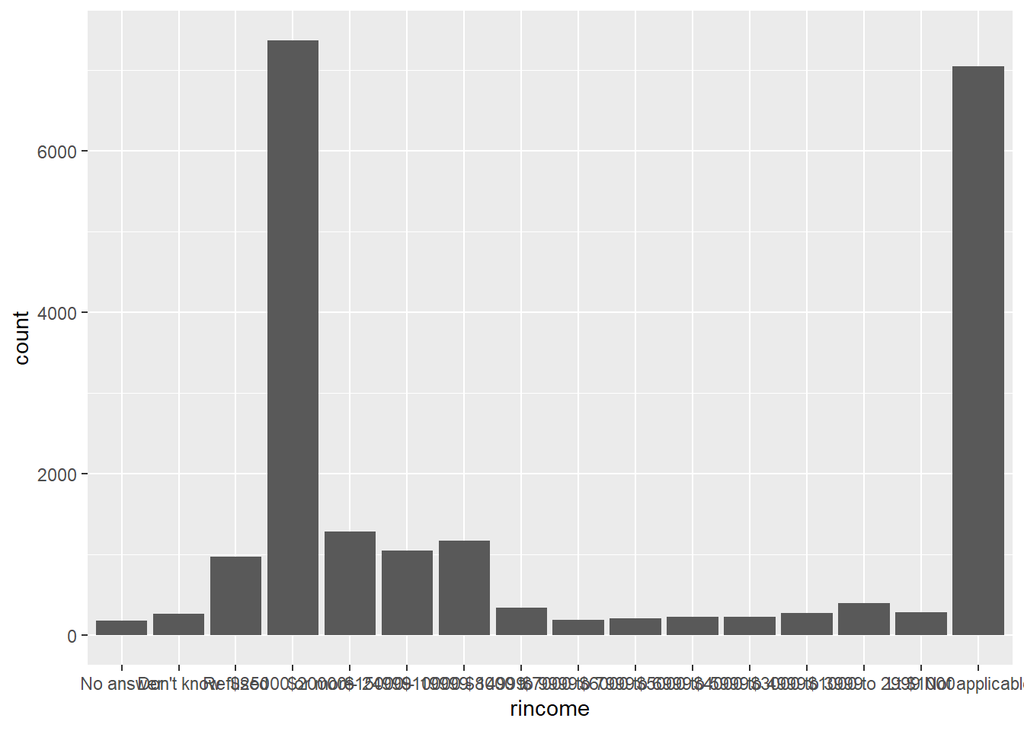

```r
ggplot(gss_cat, aes(x = rincome)) + geom_bar()
```

label들이 겹쳐져 있어 각 막대가 무엇을 나타내는 지 파악하기 어렵습니다

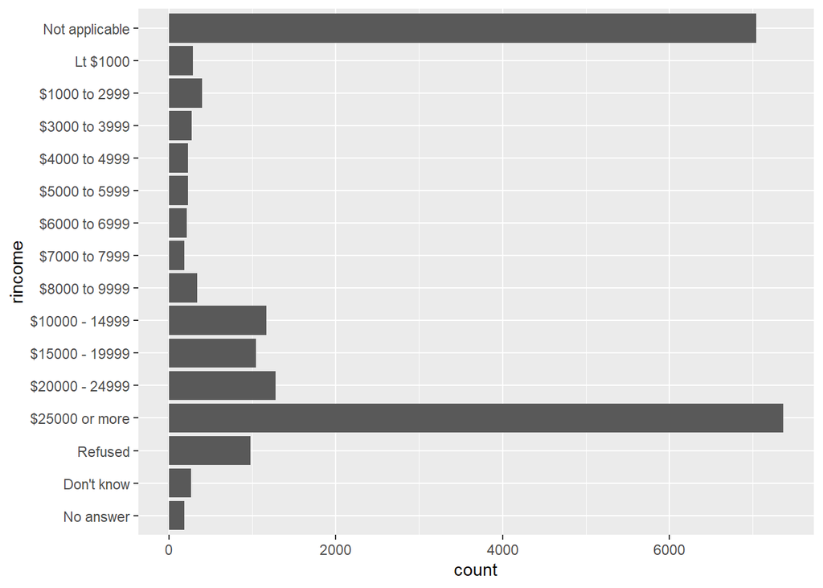

```r
ggplot(gss_cat, aes(x = rincome)) + geom_bar() + coord_flip()
```

그래프를 뒤집으면 label을 읽을 수 있습니다.

# Textbook 15.4.1

## Problem 2

```r
is.factor(gss_cat$year)
```

```
## [1] FALSE
```

```r
is.factor(gss_cat$marital)
```

```
## [1] TRUE
```

```r
is.factor(gss_cat$age)
```

```
## [1] FALSE
```

```r
is.factor(gss_cat$race)
```

```
## [1] TRUE
```

```r
is.factor(gss_cat$rincome)
```

```
## [1] TRUE
```

```r
is.factor(gss_cat$partyid)
```

```
## [1] TRUE
```

```r
is.factor(gss_cat$relig)
```

```
## [1] TRUE
```

```r
is.factor(gss_cat$denom)
```

```
## [1] TRUE
```

```r
is.factor(gss_cat$tvhours)
```

```
## [1] FALSE
```

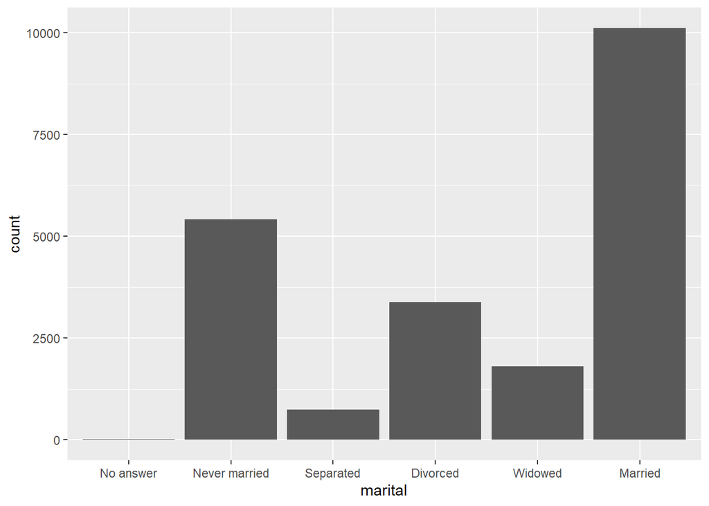

```r
ggplot(gss_cat) + geom_bar(mapping = aes(x = marital))
```

never married, separated, divorced, widowed, married 순으로 되어 있습니다 미혼부터 결혼까지 순서로 principled 하다고 생각합니다.

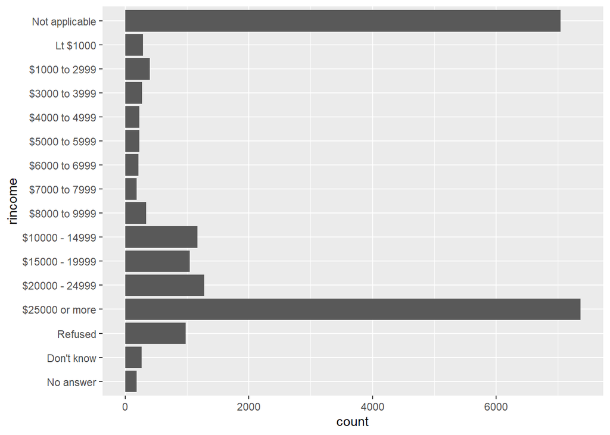

```r
ggplot(gss_cat) + geom_bar(mapping = aes(x = rincome)) + coord_flip()
```

적은 소득 부터 많은 소득 까지 순서대로 되어있어 principled 하다고 생각합니다. 하지만 하나 이상한점은 not applicable이 맨 위에 있는 점입니다.

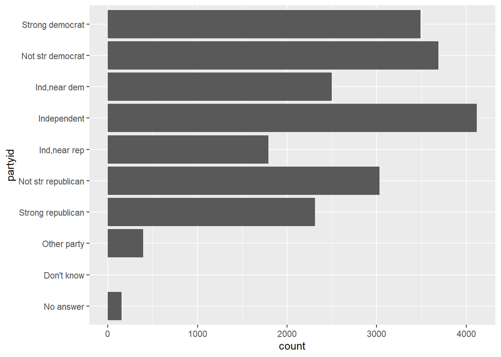

```r
ggplot(gss_cat) + geom_bar(mapping = aes(x = partyid)) + coord_flip()
```

strong democrat부터 strong republican 순으로 되어 있으며, other party, don’t know, no answer은 아래에 위치해 있습니다. 따라서 principled 하다고 생각합니다.

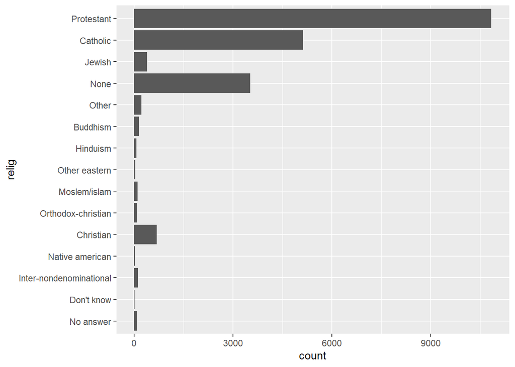

```r
ggplot(gss_cat) + geom_bar(mapping = aes(x = relig)) + coord_flip()
```

relig의 level은 특정 체계에 따라 정리되어 있다고 생각하지 않습니다. 그래서 arbitrary합니다.

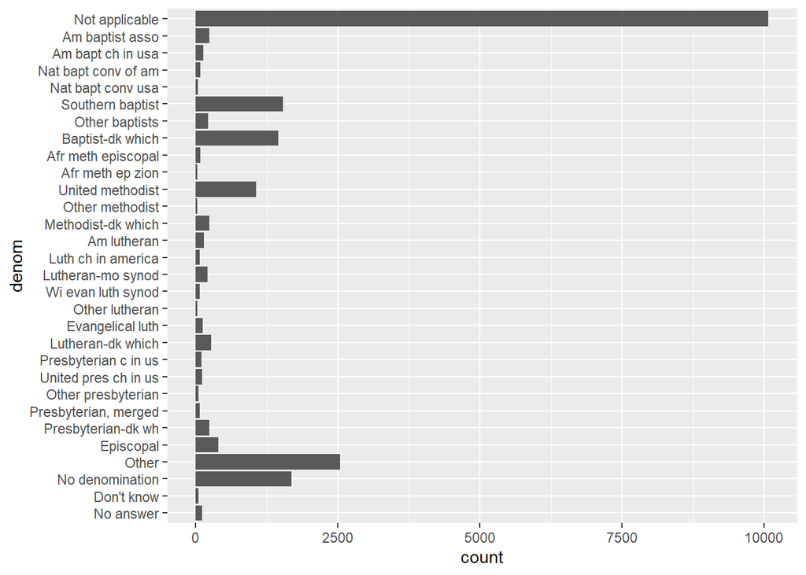

```r
ggplot(gss_cat) + geom_bar(mapping = aes(x = denom)) + coord_flip()
```

denom의 level은 특정 체계에 따라 정리되어 있다고 생각하지 않습니다. 그래서 arbitrary합니다.

# Textbook 15.5.1

## Problem 1

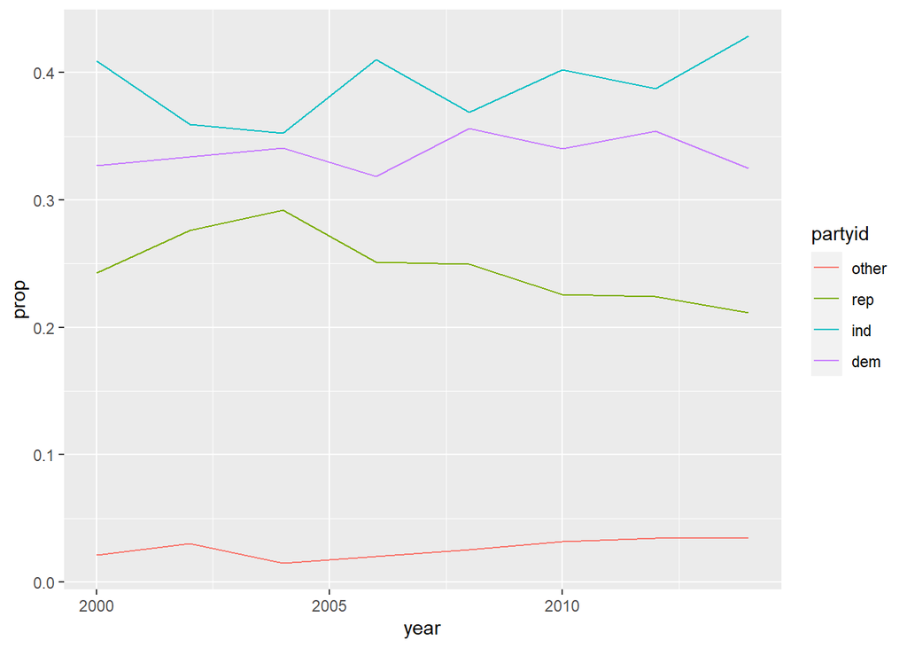

```r
gss_cat %>%
  mutate(partyid = fct_collapse(partyid,
    other = c("No answer", "Don't know", "Other party"),
    rep = c("Strong republican", "Not str republican"),
    ind = c("Ind,near rep", "Independent", "Ind,near dem"),
    dem = c("Not str democrat", "Strong democrat")
  )) %>% group_by(year) %>% count(year, partyid) %>% mutate(prop = n / sum(n)) %>% ggplot() + geom_line(mapping = aes(x = year, y = prop, color = partyid))
```

republican 은 시간이 지남에 따라 감소했으며, independent는 줄어들다가 다시 증가했습니다. 그리고 democrat은 약간의 증감은 있으나 큰 차이를 보이지는 않습니다.

# Textbook 16.2.4

## Problem 2

```r
today(tzone = "UTC")
```

```
## [1] "2022-11-08"
```

tzone은 현재 시간을 알고 싶은 지역을 특정합니다. 지역에 따라 날짜가 다를 수 있으므로 시간대를 지정해줄 필요가 있습니다. tzone의 default는 컴퓨터의 timezone입니다.

# Textbook 16.3.4

## Problem 6

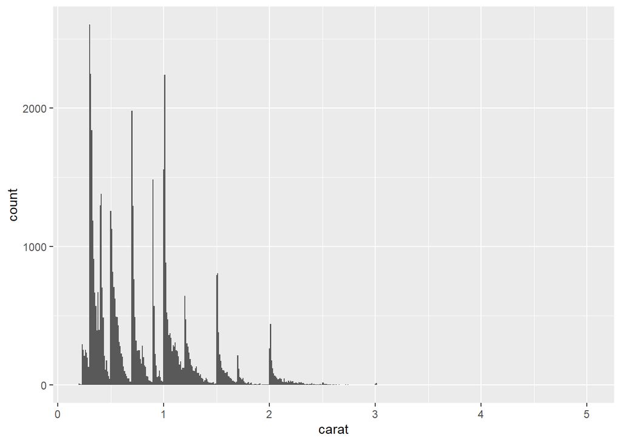

```r
diamonds %>%
  ggplot() +
  geom_histogram(mapping = aes(x = carat), binwidth = 0.01)
```

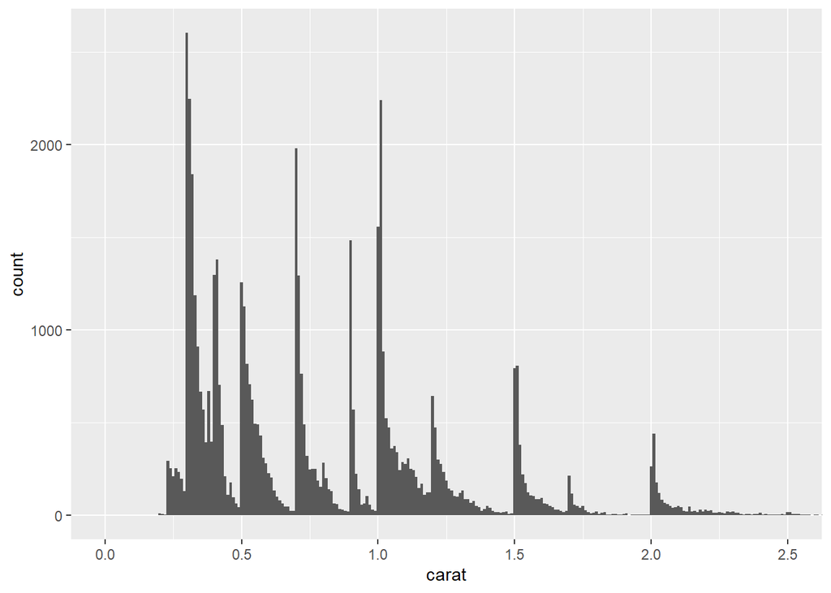

```r
diamonds %>%
  ggplot() +
  geom_histogram(mapping = aes(x = carat), binwidth = 0.01) + coord_cartesian(xlim = c(0, 2.5))
```

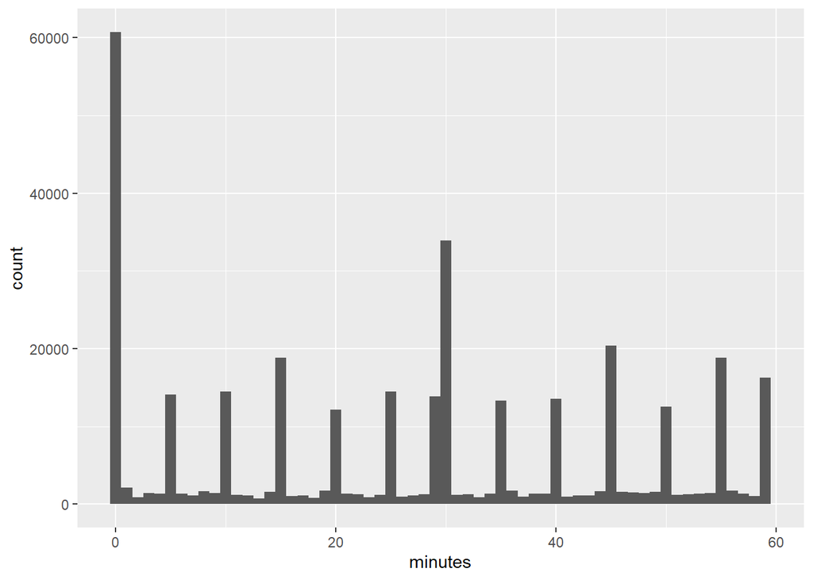

```r
flights %>% mutate(minutes = sched_dep_time %% 100) %>% ggplot() +
  geom_histogram(mapping = aes(x = minutes), binwidth = 1)
```

# Textbook 16.4.5

## Problem 4

```r
korean <- function(x){
 year(today()) - year(x) + 1
}

world <- function(x){
 (x %--% today()) %/% years(1)
}

korean(ymd("2002,11,19"))
```

```
## [1] 21
```

```r
world(ymd("2002,11,19"))
```

```
## [1] 19
```